# High Performance Computing Week 1 Assignment

Daipayan Bera

01-31-2025

```r
#Clearing environment
rm(list = ls())
library(foreach)
library(doParallel) #Importing doParallel package
```

**Q1: Importing required library to import data**

```r
library(MASS)
data("Boston")
registerDoSEQ() #Verifying that we are working with serially
```

**Q1: Creating 100 Bootstrap samples of the dataset with the SAME dimension using REPLACE=TRUE**

```r
n <- nrow(Boston)
Rprof("serial_sampling")
set.seed("143")
boston_bootstrap <- foreach(i=1:100) %do% {Boston[sample(n, n, replace = TRUE), ]}
Rprof(NULL)
summaryRprof('serial_sampling')
```

|  | self.time | self.pct | total.time | total.pct |
| --- | --- | --- | --- | --- |
| "accumulate.iforeach" | 0.04 | 40 | 0.06 | 60 |
| "doTryCatch" | 0.02 | 20 | 0.10 | 100 |
| "" | 0.02 | 20 | 0.02 | 20 |
| "stopifnot" | 0.02 | 20 | 0.02 | 20 |

|  | total.time | total.pct | self.time | self.pct |
| --- | --- | --- | --- | --- |
| "doTryCatch" | 0.10 | 100 | 0.02 | 20 |
| "%do%" | 0.10 | 100 | 0.00 | 0 |
| "e$fun" | 0.10 | 100 | 0.00 | 0 |
| "tryCatch" | 0.10 | 100 | 0.00 | 0 |
| "tryCatchList" | 0.10 | 100 | 0.00 | 0 |
| "tryCatchOne" | 0.10 | 100 | 0.00 | 0 |
| "accumulate.iforeach" | 0.06 | 60 | 0.04 | 40 |
| "accumulate" | 0.06 | 60 | 0.00 | 0 |
| "accumulator" | 0.06 | 60 | 0.00 | 0 |
| "" | 0.02 | 20 | 0.02 | 20 |

[output cut: 9 more lines]

```
$sample.interval
[1] 0.02

$sampling.time
[1] 0.1
```

*So, here I have used FOREACH function with %DO% to recieve a list of dataframes after bootstraping, by using the SAMPLE function. I have also used RPROF to see how proficient is the segment in terms of time complexity.*

**Q1: Fitting GLM model on each bootstrap sample**

```r
Rprof("serial_model")
boston_bootstrap.lm <- foreach(i=1:100) %do% {glm(medv~., data=boston_bootstrap[[i]])}
Rprof(NULL)
summaryRprof("serial_model")
```

|  | self.time | self.pct | total.time | total.pct |
| --- | --- | --- | --- | --- |
| "glm.fit" | 0.08 | 22.22 | 0.12 | 33.33 |
| "model.matrix.default" | 0.04 | 11.11 | 0.12 | 33.33 |
| ".Call" | 0.04 | 11.11 | 0.04 | 11.11 |
| "FUN" | 0.04 | 11.11 | 0.04 | 11.11 |
| "tryCatch" | 0.02 | 5.56 | 0.36 | 100.00 |
| "vapply" | 0.02 | 5.56 | 0.06 | 16.67 |
| ".External" | 0.02 | 5.56 | 0.02 | 5.56 |
| "anyDuplicated.default" | 0.02 | 5.56 | 0.02 | 5.56 |
| "model.response" | 0.02 | 5.56 | 0.02 | 5.56 |
| "names" | 0.02 | 5.56 | 0.02 | 5.56 |

[output cut: 2 more lines]

|  | total.time | total.pct | self.time | self.pct |
| --- | --- | --- | --- | --- |
| "tryCatch" | 0.36 | 100.00 | 0.02 | 5.56 |
| "%do%" | 0.36 | 100.00 | 0.00 | 0.00 |
| "doTryCatch" | 0.36 | 100.00 | 0.00 | 0.00 |
| "e$fun" | 0.36 | 100.00 | 0.00 | 0.00 |
| "tryCatchList" | 0.36 | 100.00 | 0.00 | 0.00 |
| "tryCatchOne" | 0.36 | 100.00 | 0.00 | 0.00 |
| "eval" | 0.32 | 88.89 | 0.00 | 0.00 |
| "glm" | 0.32 | 88.89 | 0.00 | 0.00 |
| "glm.fit" | 0.12 | 33.33 | 0.08 | 22.22 |
| "model.matrix.default" | 0.12 | 33.33 | 0.04 | 11.11 |

[output cut: 28 more lines]

```
$sample.interval
[1] 0.02

$sampling.time
[1] 0.36
```

*By using the same principle, I have recieved a list of the all fitted model. I have utlized all independent variables as predictor and MEDV as outcome variable.*

**Q2: Retrieving model statistics for all fitted models**

```r
if (!requireNamespace("broom", quietly = TRUE)) {
  install.packages("broom")
}
library(broom)
```

*Here, I wanted to receive the model statistics as a dataframe which further could be used for plotting. So I took help of BROOM package (https://cran.r-project.org/web/packages/broom/vignettes/broom.html). It has three main functions, 1. Tidy, 2. Augment, 3. Glance. Here, I am going to use GLANCE. It provides one row summary of all model performance statistics that we are interested in.*

*But the issue is that, if we apply this as function on the list, it is going to provide 100 statistic dataframes of each model. As we want a consolidated dataframe for all model statistics, therefore, I am going to use RBIND with DO.APPLY on the list of dataframes (Returned from GLANCE function)*

```r
Rprof("serial_statistics")
boston_boot.lm.fit <- foreach(i=1:100) %do% {
  glance(boston_bootstrap.lm[[i]])}
Rprof(NULL)
summaryRprof("serial_statistics")
```

|  | self.time | self.pct | total.time | total.pct |
| --- | --- | --- | --- | --- |
| "grepl" | 0.06 | 6.98 | 0.10 | 11.63 |
| "FUN" | 0.04 | 4.65 | 0.12 | 13.95 |
| "modifyList" | 0.04 | 4.65 | 0.10 | 11.63 |
| "file" | 0.04 | 4.65 | 0.06 | 6.98 |
| "%in%" | 0.04 | 4.65 | 0.04 | 4.65 |
| "file.exists" | 0.04 | 4.65 | 0.04 | 4.65 |
| "match.fun" | 0.04 | 4.65 | 0.04 | 4.65 |
| "stopifnot" | 0.04 | 4.65 | 0.04 | 4.65 |
| "str.default" | 0.02 | 2.33 | 0.64 | 74.42 |
| "do.call" | 0.02 | 2.33 | 0.62 | 72.09 |

[output cut: 24 more lines]

|  | total.time | total.pct | self.time | self.pct |
| --- | --- | --- | --- | --- |
| "doTryCatch" | 0.84 | 97.67 | 0.00 | 0.00 |
| "tryCatch" | 0.84 | 97.67 | 0.00 | 0.00 |
| "tryCatchList" | 0.84 | 97.67 | 0.00 | 0.00 |
| "tryCatchOne" | 0.84 | 97.67 | 0.00 | 0.00 |
| "try" | 0.68 | 79.07 | 0.00 | 0.00 |
| "str.default" | 0.64 | 74.42 | 0.02 | 2.33 |
| "...elt" | 0.64 | 74.42 | 0.00 | 0.00 |
| ".rs.describeObject" | 0.64 | 74.42 | 0.00 | 0.00 |
| ".rs.valueContents" | 0.64 | 74.42 | 0.00 | 0.00 |
| ".rs.valueContentsImpl" | 0.64 | 74.42 | 0.00 | 0.00 |

[output cut: 100 more lines]

```
$sample.interval
[1] 0.02

$sampling.time
[1] 0.86
```

*Applying RBIND on the list of one-row dataframes*

```r
bootstrap_statistics <- do.call(rbind, boston_boot.lm.fit)
```

```r
#Lets check the data that we have recieved
head(bootstrap_statistics)
```

| null.deviance | df.null | logLik | AIC | BIC | deviance | df.residual | nobs |
| --- | --- | --- | --- | --- | --- | --- | --- |
| 37056.00 | 505 | -1479.617 | 2989.235 | 3052.633 | 10269.67 | 492 | 506 |
| 36401.96 | 505 | -1497.229 | 3024.458 | 3087.856 | 11010.01 | 492 | 506 |
| 43051.53 | 505 | -1480.867 | 2991.734 | 3055.132 | 10320.51 | 492 | 506 |
| 42876.26 | 505 | -1479.256 | 2988.512 | 3051.910 | 10255.00 | 492 | 506 |
| 44330.19 | 505 | -1478.495 | 2986.990 | 3050.388 | 10224.21 | 492 | 506 |
| 41616.07 | 505 | -1502.748 | 3035.497 | 3098.895 | 11252.85 | 492 | 506 |

**Q3: Now, I was asked to “Aggregate the model fit statistics across the 100 bootstrapped samples and plot the results”. So I am choosing MEAN as aggregation.**

```r
bootstrap_statistics.mean <- data.frame(apply(bootstrap_statistics,2, mean))
bootstrap_statistics.mean
```

|  | apply.bootstrap_statistics..2..mean. |
| --- | --- |
| null.deviance | 42764.190 |
| df.null | 505.000 |
| logLik | -1487.488 |
| AIC | 3004.977 |
| BIC | 3068.375 |
| deviance | 10674.091 |
| df.residual | 492.000 |
| nobs | 506.000 |

*But, here I ran into a problem, as I typecasted the resultant vector as dataframe. It always showed the statistic names as index or something. No matter what I did to change/remove with my ability. It didn’t get affected at all. Also, when I used it to plot, it also didn’t appear in the axis. So, I went ahead and crated a separate column with the same entries.*

```r
bootstrap_statistics.mean["Statistics"] = c("null.deviance","df.null","logLik","AIC","BIC","deviance","df.residual","nobs")
names(bootstrap_statistics.mean)[1] = "Mean"
bootstrap_statistics.mean
```

|  | Mean | Statistics |
| --- | --- | --- |
| null.deviance | 42764.190 | null.deviance |
| df.null | 505.000 | df.null |
| logLik | -1487.488 | logLik |
| AIC | 3004.977 | AIC |
| BIC | 3068.375 | BIC |
| deviance | 10674.091 | deviance |
| df.residual | 492.000 | df.residual |
| nobs | 506.000 | nobs |

*Although, it’s still there, but now I have what I need to create a bar plot of the statistic.*

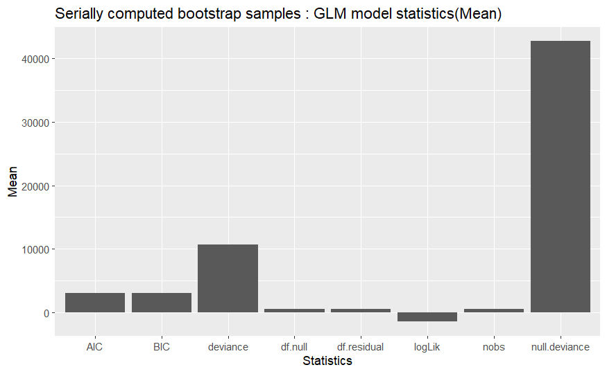

```r
library(ggplot2)
serial.plot <-ggplot(data = bootstrap_statistics.mean, aes(x = Statistics, y = Mean)) +
  geom_col() + #Using geom_bar gave stat_count() error, cause for geom_bar, y variable takes a categorical variable as input
  labs(title = "Serially computed bootstrap samples : GLM model statistics(Mean)")
serial.plot
```

**Q3: Computing all other model statistics**

```r
summary(bootstrap_statistics)
```

```
 null.deviance      df.null        logLik           AIC            BIC
 Min.   :36402   Min.   :505   Min.   :-1550   Min.   :2860   Min.   :2924
 1st Qu.:40408   1st Qu.:505   1st Qu.:-1507   1st Qu.:2963   1st Qu.:3027
 Median :42823   Median :505   Median :-1487   Median :3005   Median :3068
 Mean   :42764   Mean   :505   Mean   :-1487   Mean   :3005   Mean   :3068
 3rd Qu.:45219   3rd Qu.:505   3rd Qu.:-1467   3rd Qu.:3044   3rd Qu.:3107
 Max.   :50916   Max.   :505   Max.   :-1415   Max.   :3131   Max.   :3194
    deviance      df.residual       nobs
 Min.   : 7961   Min.   :492   Min.   :506
 1st Qu.: 9757   1st Qu.:492   1st Qu.:506
 Median :10590   Median :492   Median :506
 Mean   :10674   Mean   :492   Mean   :506
 3rd Qu.:11437   3rd Qu.:492   3rd Qu.:506
 Max.   :13585   Max.   :492   Max.   :506
```

**Q4. Creating bootstrap samples parallelly with foreach function**

```r
cl <- makeCluster(detectCores(), type='PSOCK')
registerDoParallel(cl)
getDoParWorkers() #Verifying that we are computing parallelly
```

```
[1] 4
```

```r
Rprof("parallel_sampling")
set.seed(143)
parallel_boot.samples <- foreach (i=1:100, .packages = c("doParallel", "foreach")) %dopar% {Boston[sample(n, n, replace = TRUE),]}
Rprof(NULL)
summaryRprof("parallel_sampling")
```

|  | self.time | self.pct | total.time | total.pct |
| --- | --- | --- | --- | --- |
| "unserialize" | 0.10 | 50 | 0.10 | 50 |
| "serialize" | 0.04 | 20 | 0.06 | 30 |
| "complete" | 0.02 | 10 | 0.02 | 10 |
| "f" | 0.02 | 10 | 0.02 | 10 |
| "summary.connection" | 0.02 | 10 | 0.02 | 10 |

|  | total.time | total.pct | self.time | self.pct |
| --- | --- | --- | --- | --- |
| "%dopar%" | 0.18 | 90 | 0.00 | 0 |
| "e$fun" | 0.18 | 90 | 0.00 | 0 |
| "clusterCall" | 0.12 | 60 | 0.00 | 0 |
| "unserialize" | 0.10 | 50 | 0.10 | 50 |
| "checkForRemoteErrors" | 0.08 | 40 | 0.00 | 0 |
| "FUN" | 0.08 | 40 | 0.00 | 0 |
| "lapply" | 0.08 | 40 | 0.00 | 0 |
| "recvData" | 0.08 | 40 | 0.00 | 0 |
| "recvData.SOCKnode" | 0.08 | 40 | 0.00 | 0 |
| "serialize" | 0.06 | 30 | 0.04 | 20 |

[output cut: 24 more lines]

```
$sample.interval
[1] 0.02

$sampling.time
[1] 0.2
```

**Fitting GLM model on each bootstrap sample (Parallelly)**

```r
Rprof("Parallel_model")
parallel_boot.models <- foreach(i=1:100, parallel_boot.samples, .packages = c("doParallel", "foreach")) %dopar% {
  glm(medv~.,data=parallel_boot.samples[[i]])
}
Rprof(NULL)
summaryRprof("Parallel_model")
```

|  | self.time | self.pct | total.time | total.pct |
| --- | --- | --- | --- | --- |
| "unserialize" | 3.86 | 94.61 | 3.86 | 94.61 |
| "serialize" | 0.16 | 3.92 | 0.16 | 3.92 |
| "sendData" | 0.02 | 0.49 | 0.18 | 4.41 |
| "f" | 0.02 | 0.49 | 0.02 | 0.49 |
| "getIterVal" | 0.02 | 0.49 | 0.02 | 0.49 |

|  | total.time | total.pct | self.time | self.pct |
| --- | --- | --- | --- | --- |
| "%dopar%" | 4.06 | 99.51 | 0.00 | 0.00 |
| "e$fun" | 4.06 | 99.51 | 0.00 | 0.00 |
| "clusterApplyLB" | 3.88 | 95.10 | 0.00 | 0.00 |
| "dynamicClusterApply" | 3.88 | 95.10 | 0.00 | 0.00 |
| "unserialize" | 3.86 | 94.61 | 3.86 | 94.61 |
| "recvOneData" | 3.86 | 94.61 | 0.00 | 0.00 |
| "recvOneData.SOCKcluster" | 3.86 | 94.61 | 0.00 | 0.00 |
| "recvOneResult" | 3.86 | 94.61 | 0.00 | 0.00 |
| "sendData" | 0.18 | 4.41 | 0.02 | 0.49 |
| "postNode" | 0.18 | 4.41 | 0.00 | 0.00 |

[output cut: 21 more lines]

```
$sample.interval
[1] 0.02

$sampling.time
[1] 4.08
```

**Q4. Retrieving model statistics for all bootstrap models (Using Parallelization)**

```r
Rprof("parallel_statistics")
parallel_boot.statistics <- foreach(i=1:100, parallel_boot.models, .packages = c("doParallel", "foreach", "broom")) %dopar% {
  glance(parallel_boot.models[[i]])
}
Rprof(NULL)
summaryRprof("parallel_statistics")
```

|  | self.time | self.pct | total.time | total.pct |
| --- | --- | --- | --- | --- |
| "serialize" | 18.88 | 93.47 | 18.88 | 93.47 |
| "unserialize" | 0.46 | 2.28 | 0.46 | 2.28 |
| "sys.call" | 0.14 | 0.69 | 0.14 | 0.69 |
| "socketSelect" | 0.10 | 0.50 | 0.10 | 0.50 |
| "file" | 0.08 | 0.40 | 0.08 | 0.40 |
| "str.default" | 0.04 | 0.20 | 0.70 | 3.47 |
| "parse" | 0.04 | 0.20 | 0.10 | 0.50 |
| "file.info" | 0.04 | 0.20 | 0.04 | 0.20 |
| "tryCatch" | 0.02 | 0.10 | 0.74 | 3.66 |
| "FUN" | 0.02 | 0.10 | 0.56 | 2.77 |

[output cut: 19 more lines]

|  | total.time | total.pct | self.time | self.pct |
| --- | --- | --- | --- | --- |
| "%dopar%" | 19.48 | 96.44 | 0.00 | 0.00 |
| "e$fun" | 19.48 | 96.44 | 0.00 | 0.00 |
| "clusterCall" | 19.30 | 95.54 | 0.00 | 0.00 |
| "postNode" | 18.90 | 93.56 | 0.00 | 0.00 |
| "sendCall" | 18.90 | 93.56 | 0.00 | 0.00 |
| "sendData" | 18.90 | 93.56 | 0.00 | 0.00 |
| "serialize" | 18.88 | 93.47 | 18.88 | 93.47 |
| "sendData.SOCKnode" | 18.88 | 93.47 | 0.00 | 0.00 |
| "tryCatch" | 0.74 | 3.66 | 0.02 | 0.10 |
| "doTryCatch" | 0.74 | 3.66 | 0.00 | 0.00 |

[output cut: 98 more lines]

```
$sample.interval
[1] 0.02

$sampling.time
[1] 20.2
```

**Q4. Retrieving a dataframe consisting all model statistics**

```r
parallel_boot.statistics.merge <- do.call(rbind, parallel_boot.statistics) #Using rbind to combine all one-row dataframes (recieved from GLANCE function) into one dataframe to better usability
parallel_boot.statistics.mean <- data.frame(apply(parallel_boot.statistics.merge,2, mean))
#Creating a separate column consisting all the model statistic labels
parallel_boot.statistics.mean["Statistics"] = c("null.deviance","df.null","logLik","AIC","BIC","deviance","df.residual","nobs")
names(parallel_boot.statistics.mean)[1] = "Mean"
parallel_boot.statistics.mean
```

|  | Mean | Statistics |
| --- | --- | --- |
| null.deviance | 41976.543 | null.deviance |
| df.null | 505.000 | df.null |
| logLik | -1481.164 | logLik |
| AIC | 2992.327 | AIC |
| BIC | 3055.725 | BIC |
| deviance | 10403.945 | deviance |
| df.residual | 492.000 | df.residual |
| nobs | 506.000 | nobs |

**Q4. Plotting aggregated (Mean) model statistics for both Parallel and Serial computing**

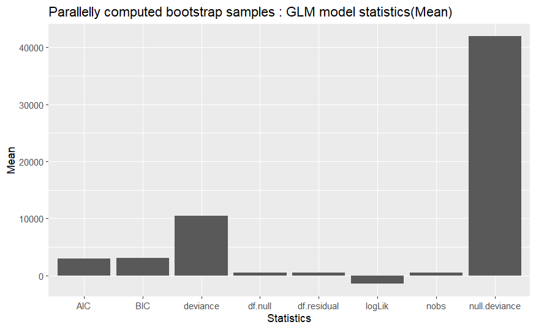

```r
ggplot(data = parallel_boot.statistics.mean, aes(x = Statistics, y = Mean))+
  geom_col()+
  labs(title = "Parallelly computed bootstrap samples : GLM model statistics(Mean)")
```

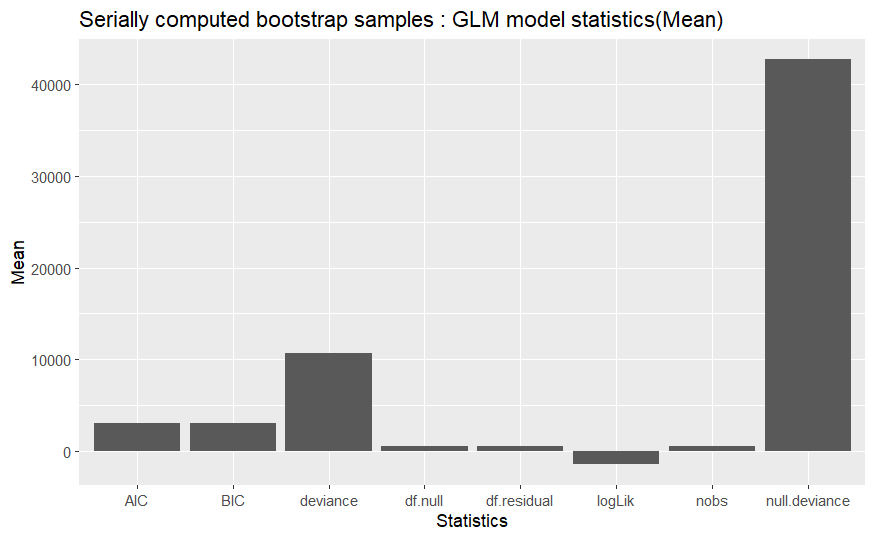

```r
serial.plot
```

```r
#Stopping cluster and parallel computing
stopCluster(cl)
registerDoSEQ()
```

###Profiling through Microbenchmark

```r
serial_bootstrap_glmfit <- function(Boston){
  n=nrow(Boston)
  library(broom)
  set.seed("143")
  serial_bootstrap <- foreach(i=1:100) %do% {Boston[sample(n, n, replace = TRUE), ]}
  serialboot_glm <-foreach(i=1:100) %do% {glm(medv~.,data=serial_bootstrap[[i]])}
  serialboot_glm_stat <- foreach(i=1:100) %do% {glance(serialboot_glm[[i]])}
  serial_stats <- do.call(rbind, serialboot_glm_stat)
}
```

```r
parallel_bootstrap_glmfit <- function(Boston){
  cl <- makeCluster(detectCores()-1, type='PSOCK')
  doParallel::registerDoParallel()
  n=nrow(Boston)
  set.seed("143")
  parallel_bootstrap <- foreach(i=1:100, .packages = c("foreach","doParallel")) %dopar% {
    Boston[sample(n, n, replace = TRUE), ]}
  parallelboot_glm <-foreach(i=1:100, .packages = c("foreach","doParallel")) %dopar% {
    glm(medv~.,data=parallel_bootstrap[[i]])}
  parallelboot_glm_stat <- foreach(i=1:100,.packages = c("foreach","doParallel","broom")) %dopar% {
    glance(parallelboot_glm[[i]])}
  parallel_stats <- do.call(rbind, parallelboot_glm_stat)
  stopCluster(cl)
  registerDoSEQ()
}
```

```r
microbenchmark::microbenchmark(
  'serial_op' = serial_bootstrap_glmfit(Boston),
  'parallel_op' = parallel_bootstrap_glmfit(Boston),
  times=10
)
```

```
Unit: milliseconds
```

| expr | min | lq | mean | median | uq | max | neval | cld |
| --- | --- | --- | --- | --- | --- | --- | --- | --- |
| serial_op | 748.3728 | 1883.153 | 3413.396 | 2225.416 | 3114.851 | 14465.1 | 10 | a |
| parallel_op | 33956.9828 | 46828.494 | 99924.673 | 127286.394 | 135778.007 | 142405.3 | 10 | b |